# Richness & Diversity

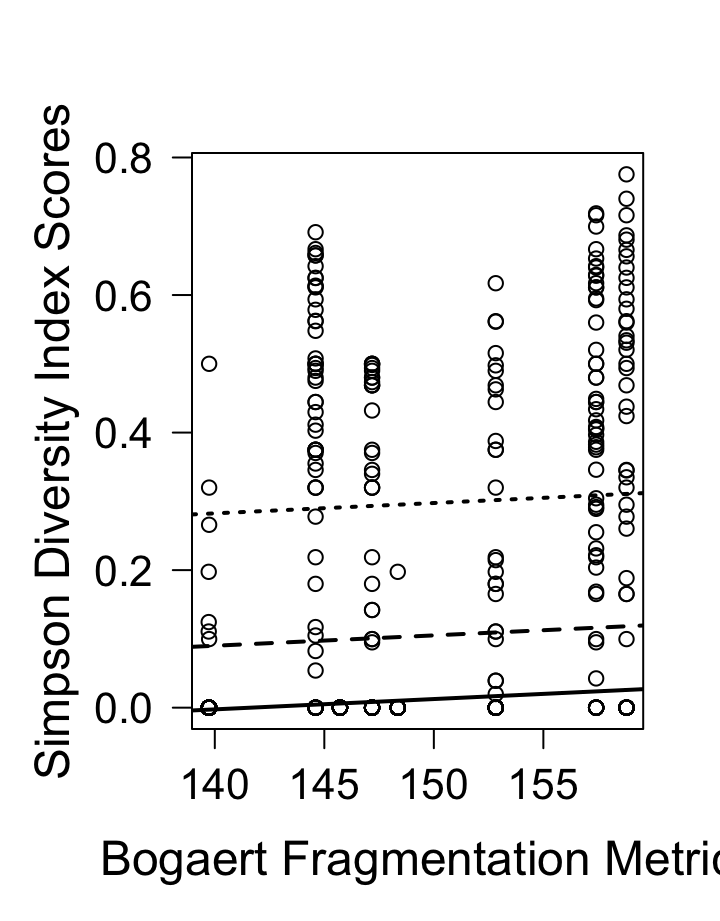

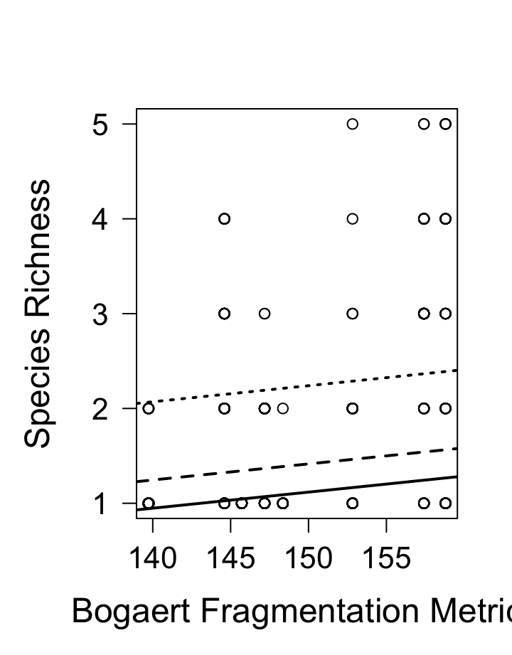

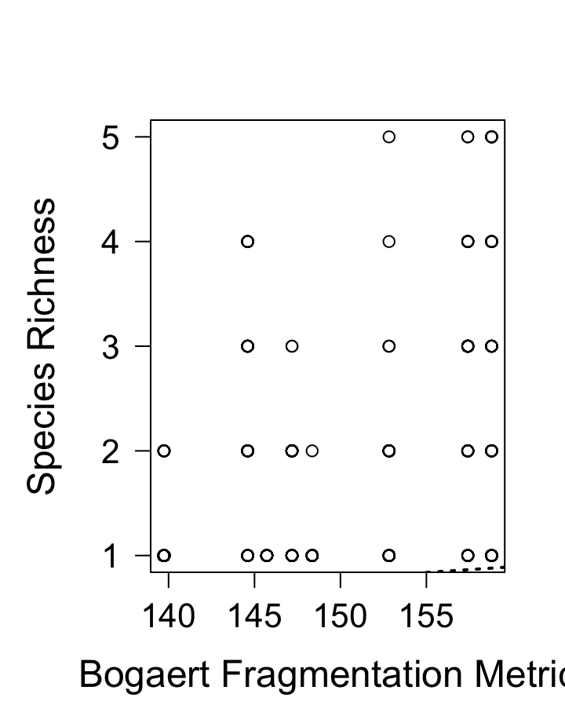

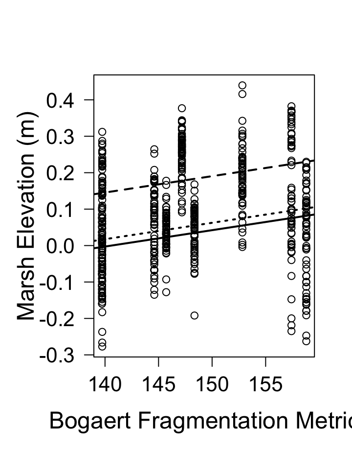

[figure not shown]

[figure not shown]

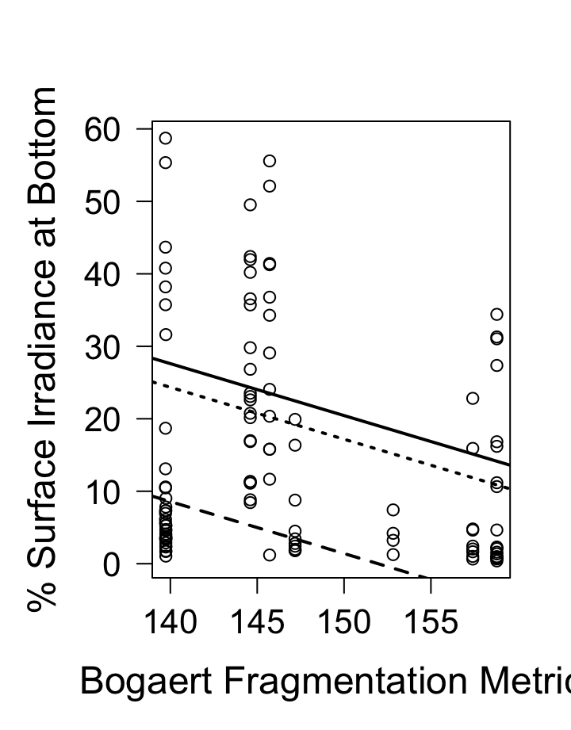

# Page 1 - Simpson 1

Model Summary

```
Linear mixed model fit by REML. t-tests use Satterthwaite's method [
lmerModLmerTest]
Formula: Simpson ~ bogaert + (1 | crms_site)
   Data: new.df

REML criterion at convergence: -300.6

Scaled residuals:
     Min       1Q   Median       3Q      Max
-1.72061 -0.55833 -0.05461  0.24827  2.81121

Random effects:
 Groups    Name        Variance Std.Dev.
 crms_site (Intercept) 0.02136  0.1461
 Residual              0.03263  0.1806
Number of obs: 560, groups:  crms_site, 3

Fixed effects:
              Estimate Std. Error         df t value Pr(>|t|)
(Intercept)  -0.087315   0.231045  91.158603  -0.378    0.706
bogaert       0.001505   0.001450 557.903857   1.038    0.300

Correlation of Fixed Effects:
        (Intr)
bogaert -0.930
```

AIC score

```
[1] -292.5812
```

R-squared values

```
             R2m       R2c
[1,] 0.001786245 0.3966868
```

For some reason that I don’t understand these sections won’t scroll down unless I add more text here and I don’t want to waste time troubleshooting it so I’m just going top do add this everywhere at the bottom of the codeblocks.

### Plotting the GLMM

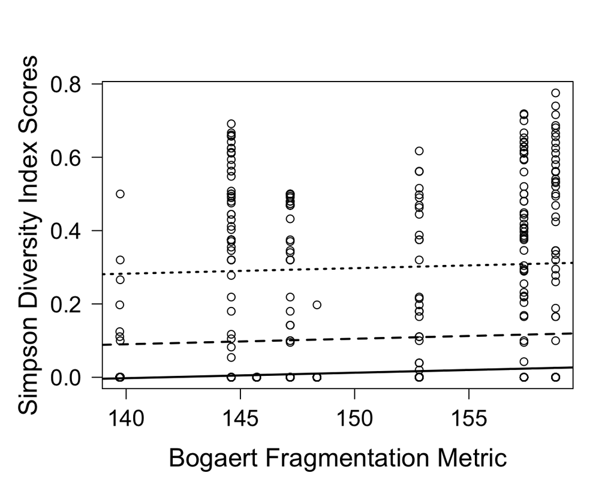

### Likelihood Ratio test

The approach to a likelihood ratio test is to compare the full model to a reduced and null model using an anova.

Basically, the test compares the fit of two models. The null hypothesis is that the smaller model is the “best” model; It is rejected when the test statistic is large. In other words, if the null hypothesis is rejected, then the larger model is a significant improvement over the smaller one.

Keep in mind that LRT-based null hypothesis tests are conservative when the null value (such as σ2=0) is on the boundary of the feasible space; in the simplest case (single random effect variance), the p-value is approximately twice as large as it should be (Pinheiro and Bates 2000).

1. Test full model against model without random effect to test for its significance

```r
m1 <- lmer(Simpson ~  bogaert + (1 | crms_site), data = new.df)
m0 <- lm(Simpson ~ bogaert, new.df)
anova(m1,m0) ## two sequential tests
```

```
Data: new.df
Models:
m0: Simpson ~ bogaert
m1: Simpson ~ bogaert + (1 | crms_site)
   Df     AIC     BIC  logLik deviance  Chisq Chi Df Pr(>Chisq)
m0  3 -181.71 -168.73  93.857  -187.71
m1  4 -307.14 -289.82 157.568  -315.14 127.42      1  < 2.2e-16 ***
---
Signif. codes:  0 '***' 0.001 '**' 0.01 '*' 0.05 '.' 0.1 ' ' 1
```

2. calculate p-values for fixed effects

```r
mixed(Simpson ~  bogaert_scaled + (1 | crms_site), data = new.df, method = 'LRT')
```

```
Fitting 2 (g)lmer() models:
[..]
```

```
Mixed Model Anova Table (Type 3 tests, LRT-method)

Model: Simpson ~ bogaert_scaled + (1 | crms_site)
Data: new.df
Df full model: 4
          Effect df Chisq p.value
1 bogaert_scaled  1  1.17     .28
---
Signif. codes:  0 '***' 0.001 '**' 0.01 '*' 0.05 '+' 0.1 ' ' 1
```

# Page 2 - Richness 1

### Model Summary - GLMM Richness ~ bogaert + (1 | crms site)

```
Linear mixed model fit by REML. t-tests use Satterthwaite's method [
lmerModLmerTest]
Formula: Richness ~ bogaert + (1 | crms_site)
   Data: new.df

REML criterion at convergence: 1301.4

Scaled residuals:
    Min      1Q  Median      3Q     Max
-1.8299 -0.4839 -0.1183  0.7072  4.6589

Random effects:
 Groups    Name        Variance Std.Dev.
 crms_site (Intercept) 0.3419   0.5847
 Residual              0.5763   0.7592
Number of obs: 560, groups:  crms_site, 3

Fixed effects:
              Estimate Std. Error         df t value Pr(>|t|)
(Intercept)  -0.954217   0.964685 104.090385  -0.989  0.32488
bogaert       0.016968   0.006091 557.763034   2.786  0.00552 **
---
Signif. codes:  0 '***' 0.001 '**' 0.01 '*' 0.05 '.' 0.1 ' ' 1

Correlation of Fixed Effects:
        (Intr)
bogaert -0.936
```

AIC score

```
[1] 1309.428
```

R-squared values

```
            R2m       R2c
[1,] 0.01319987 0.3806454
```

For some reason that I don’t understand these sections won’t scroll down unless I add more text here and I don’t want to waste time troubleshooting it so I’m just going top do add this everywhere at the bottom of the codeblocks.

### Plotting the GLMM

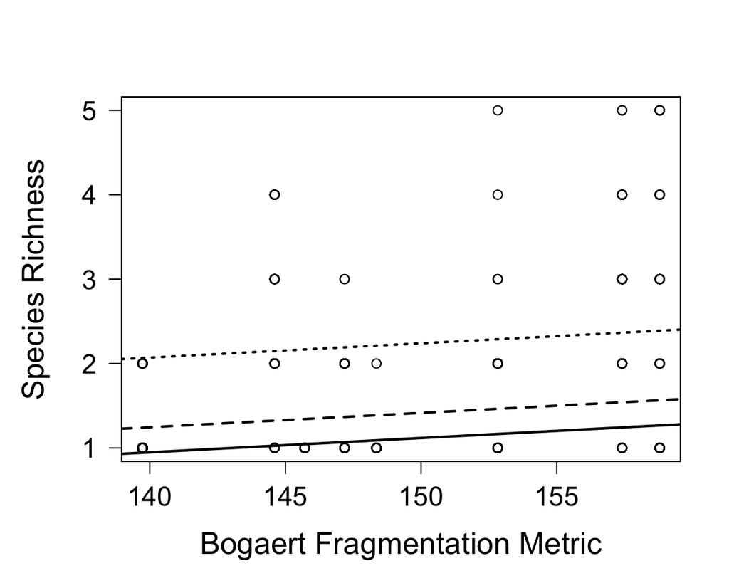

### Likelihood Ratio test

1. Random Effect

```
Data: new.df
Models:
m0: Richness ~ bogaert
m2: Richness ~ bogaert + (1 | crms_site)
   Df    AIC    BIC  logLik deviance  Chisq Chi Df Pr(>Chisq)
m0  3 1413.9 1426.9 -703.94   1407.9
m2  4 1300.5 1317.8 -646.26   1292.5 115.37      1  < 2.2e-16 ***
---
Signif. codes:  0 '***' 0.001 '**' 0.01 '*' 0.05 '.' 0.1 ' ' 1
```

2. calculate p-values for fixed effects

```
Fitting 2 (g)lmer() models:
[..]
```

```
Mixed Model Anova Table (Type 3 tests, LRT-method)

Model: Richness ~ bogaert_scaled + (1 | crms_site)
Data: new.df
Df full model: 4
          Effect df   Chisq p.value
1 bogaert_scaled  1 7.92 **    .005
---
Signif. codes:  0 '***' 0.001 '**' 0.01 '*' 0.05 '+' 0.1 ' ' 1
```

For some reason that I don’t understand these sections won’t scroll down unless I add more text here and I don’t want to waste time troubleshooting it so I’m just going top do add this everywhere at the bottom of the codeblocks.

# Page 3 - Richness 3

### Model Summary - GLMM Richness ~ bogaert + (1 | crms site) famil = ‘poisson’

```
Generalized linear mixed model fit by maximum likelihood (Laplace
  Approximation) [glmerMod]
 Family: poisson  ( log )
Formula: Richness ~ bogaert + (1 | crms_site)
   Data: new.df

     AIC      BIC   logLik deviance df.resid
  1450.8   1463.8   -722.4   1444.8      557

Scaled residuals:
     Min       1Q   Median       3Q      Max
-0.90820 -0.26402 -0.05184  0.38015  2.94314

Random effects:
 Groups    Name        Variance Std.Dev.
 crms_site (Intercept) 0.08446  0.2906
Number of obs: 560, groups:  crms_site, 3

Fixed effects:
             Estimate Std. Error z value Pr(>|z|)
(Intercept) -1.220687   0.938833  -1.300   0.1935
bogaert      0.010849   0.006215   1.746   0.0809 .
---
Signif. codes:  0 '***' 0.001 '**' 0.01 '*' 0.05 '.' 0.1 ' ' 1

Correlation of Fixed Effects:
        (Intr)
bogaert -0.983
convergence code: 0
Model is nearly unidentifiable: very large eigenvalue
 - Rescale variables?
```

AIC score

```
[1] 1450.77
```

R-squared values

```
                  R2m        R2c
delta     0.006873836 0.12249322
lognormal 0.008586434 0.15301207
trigamma  0.005139764 0.09159168
```

For some reason that I don’t understand these sections won’t scroll down unless I add more text here and I don’t want to waste time troubleshooting it so I’m just going top do add this everywhere at the bottom of the codeblocks.

### Plotting the GLMM

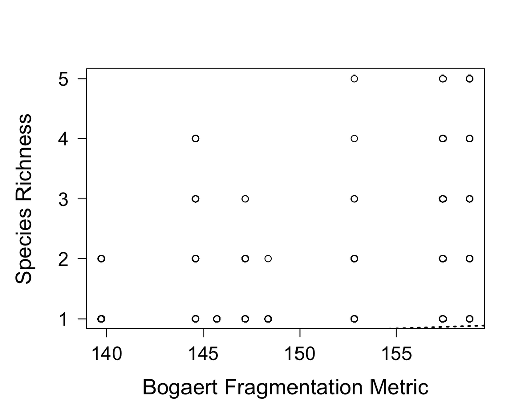

### Likelihood Ratio test

1. Random effect

```
Data: new.df
Models:
m3: Richness ~ bogaert + (1 | crms_site)
m0: Richness ~ bogaert
   Df    AIC    BIC  logLik deviance  Chisq Chi Df Pr(>Chisq)
m3  3 1450.8 1463.8 -722.38   1444.8
m0  3 1413.9 1426.9 -703.94   1407.9 36.881      0  < 2.2e-16 ***
---
Signif. codes:  0 '***' 0.001 '**' 0.01 '*' 0.05 '.' 0.1 ' ' 1
```

2. calculate p-values for fixed effects

```
Fitting 2 (g)lmer() models:
[..]
```

[output not shown]

For some reason that I don’t understand these sections won’t scroll down unless I add more text here and I don’t want to waste time troubleshooting it so I’m just going top do add this everywhere at the bottom of the codeblocks.

# Page 4 - Elevation 1

### Model Summary - GLMM Marsh Elevation ~ bogaert + (1 | crms site)

```
Linear mixed model fit by REML. t-tests use Satterthwaite's method [
lmerModLmerTest]
Formula: correct_elev_m ~ bogaert + (1 | crms_site)
   Data: new.df

REML criterion at convergence: -811.1

Scaled residuals:
    Min      1Q  Median      3Q     Max
-3.6999 -0.5365  0.1039  0.6131  2.5146

Random effects:
 Groups    Name        Variance Std.Dev.
 crms_site (Intercept) 0.006549 0.08092
 Residual              0.012978 0.11392
Number of obs: 557, groups:  crms_site, 3

Fixed effects:
              Estimate Std. Error         df t value Pr(>|t|)
(Intercept) -5.760e-01  1.435e-01  1.294e+02  -4.014    1e-04 ***
bogaert      4.496e-03  9.144e-04  5.543e+02   4.917 1.16e-06 ***
---
Signif. codes:  0 '***' 0.001 '**' 0.01 '*' 0.05 '.' 0.1 ' ' 1

Correlation of Fixed Effects:
        (Intr)
bogaert -0.945
```

AIC score

```
[1] -803.1034
```

R-squared values

```
           R2m       R2c
[1,] 0.0425134 0.3636245
```

For some reason that I don’t understand these sections won’t scroll down unless I add more text here and I don’t want to waste time troubleshooting it so I’m just going top do add this everywhere at the bottom of the codeblocks.

### Plotting the GLMM

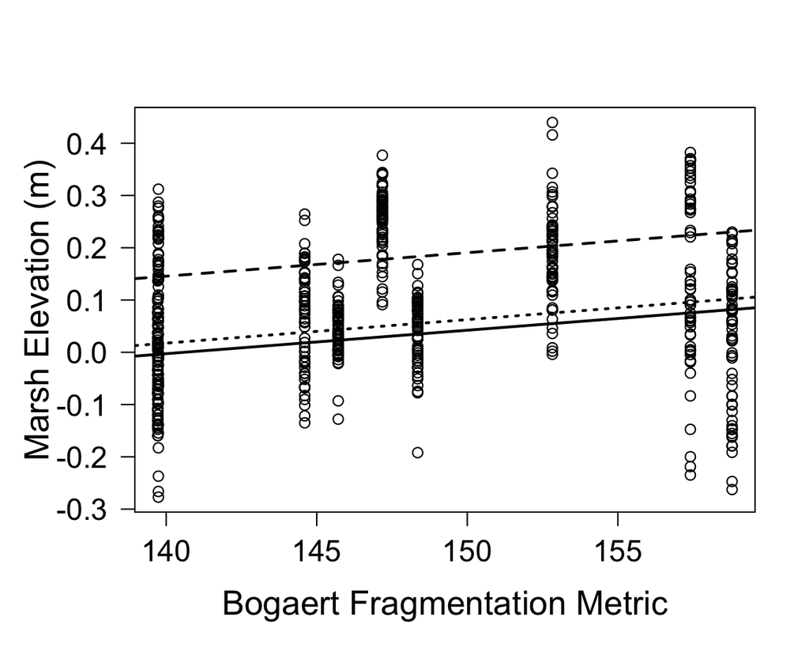

### Likelihood Ratio test

1. Random effect

```
Data: new.df
Models:
m0: correct_elev_m ~ bogaert
m4: correct_elev_m ~ bogaert + (1 | crms_site)
   Df     AIC     BIC logLik deviance  Chisq Chi Df Pr(>Chisq)
m0  3 -675.99 -663.02 341.00  -681.99
m4  4 -819.76 -802.47 413.88  -827.76 145.77      1  < 2.2e-16 ***
---
Signif. codes:  0 '***' 0.001 '**' 0.01 '*' 0.05 '.' 0.1 ' ' 1
```

2. calculate p-values for fixed effects

```
Fitting 2 (g)lmer() models:
[..]
```

```
Mixed Model Anova Table (Type 3 tests, LRT-method)

Model: correct_elev_m ~ bogaert_scaled + (1 | crms_site)
Data: new.df
Df full model: 4
          Effect df     Chisq p.value
1 bogaert_scaled  1 23.68 ***  <.0001
---
Signif. codes:  0 '***' 0.001 '**' 0.01 '*' 0.05 '+' 0.1 ' ' 1
```

For some reason that I don’t understand these sections won’t scroll down unless I add more text here and I don’t want to waste time troubleshooting it so I’m just going top do add this everywhere at the bottom of the codeblocks.

# Page 5 - Simpson 2

### Model Summary - GLMM Simposon’s Index ~ elevation + bogaert + (1 | crms site)

```
Linear mixed model fit by REML. t-tests use Satterthwaite's method [
lmerModLmerTest]
Formula: Simpson ~ correct_elev_m + bogaert + (1 | crms_site)
   Data: new.df

REML criterion at convergence: -362.4

Scaled residuals:
    Min      1Q  Median      3Q     Max
-2.6995 -0.6204 -0.0977  0.3887  3.1873

Random effects:
 Groups    Name        Variance Std.Dev.
 crms_site (Intercept) 0.02432  0.1559
 Residual              0.02894  0.1701
Number of obs: 557, groups:  crms_site, 3

Fixed effects:
                 Estimate Std. Error         df t value Pr(>|t|)
(Intercept)     2.318e-01  2.249e-01  6.732e+01   1.031    0.306
correct_elev_m  5.472e-01  6.343e-02  5.537e+02   8.627   <2e-16 ***
bogaert        -9.805e-04  1.396e-03  5.540e+02  -0.702    0.483
---
Signif. codes:  0 '***' 0.001 '**' 0.01 '*' 0.05 '.' 0.1 ' ' 1

Correlation of Fixed Effects:
            (Intr) crrc__
corrct_lv_m  0.163
bogaert     -0.915 -0.205
```

AIC score

```
[1] -352.3984
```

R-squared values

```
            R2m       R2c
[1,] 0.08892146 0.5049509
```

For some reason that I don’t understand these sections won’t scroll down unless I add more text here and I don’t want to waste time troubleshooting it so I’m just going top do add this everywhere at the bottom of the codeblocks.

### Likelihood Ratio test

1. Random Effect

```
Data: new.df
Models:
m0: Simpson ~ correct_elev_m + bogaert
m5: Simpson ~ correct_elev_m + bogaert + (1 | crms_site)
   Df     AIC     BIC logLik deviance  Chisq Chi Df Pr(>Chisq)
m0  4 -215.39 -198.10 111.69  -223.39
m5  5 -370.62 -349.01 190.31  -380.62 157.23      1  < 2.2e-16 ***
---
Signif. codes:  0 '***' 0.001 '**' 0.01 '*' 0.05 '.' 0.1 ' ' 1
```

2. calculate p-values for fixed effects

```
Fitting 3 (g)lmer() models:
[...]
```

```
Mixed Model Anova Table (Type 3 tests, LRT-method)

Model: Simpson ~ elevation_scaled + bogaert_scaled + (1 | crms_site)
Data: [
Data: new.df
Data: is.na(new.df$correct_elev_m) != TRUE
Data:
Df full model: 5
            Effect df     Chisq p.value
1 elevation_scaled  1 69.90 ***  <.0001
2   bogaert_scaled  1      0.43     .51
---
Signif. codes:  0 '***' 0.001 '**' 0.01 '*' 0.05 '+' 0.1 ' ' 1
```

For some reason that I don’t understand these sections won’t scroll down unless I add more text here and I don’t want to waste time troubleshooting it so I’m just going top do add this everywhere at the bottom of the codeblocks.

# Page 6 - Richness 3

### Model Summary - Richness ~ elevation + bogaert + (1 | crms site)

```
Linear mixed model fit by REML. t-tests use Satterthwaite's method [
lmerModLmerTest]
Formula: Richness ~ correct_elev_m + bogaert + (1 | crms_site)
   Data: new.df

REML criterion at convergence: 1218.1

Scaled residuals:
    Min      1Q  Median      3Q     Max
-2.8797 -0.5690 -0.1005  0.4916  4.6049

Random effects:
 Groups    Name        Variance Std.Dev.
 crms_site (Intercept) 0.4142   0.6436
 Residual              0.5017   0.7083
Number of obs: 557, groups:  crms_site, 3

Fixed effects:
                Estimate Std. Error        df t value Pr(>|t|)
(Intercept)    4.768e-01  9.351e-01 6.903e+01   0.510    0.612
correct_elev_m 2.450e+00  2.641e-01 5.537e+02   9.277   <2e-16 ***
bogaert        5.825e-03  5.815e-03 5.540e+02   1.002    0.317
---
Signif. codes:  0 '***' 0.001 '**' 0.01 '*' 0.05 '.' 0.1 ' ' 1

Correlation of Fixed Effects:
            (Intr) crrc__
corrct_lv_m  0.163
bogaert     -0.917 -0.205
```

AIC score

```
[1] 1228.06
```

R-squared values

```
           R2m      R2c
[1,] 0.1091411 0.512034
```

For some reason that I don’t understand these sections won’t scroll down unless I add more text here and I don’t want to waste time troubleshooting it so I’m just going top do add this everywhere at the bottom of the codeblocks.

### Likelihood Ratio test

1. Random Effect

```
Data: new.df
Models:
m0: Richness ~ correct_elev_m + bogaert
m6: Richness ~ correct_elev_m + bogaert + (1 | crms_site)
   Df    AIC    BIC  logLik deviance  Chisq Chi Df Pr(>Chisq)
m0  4 1371.0 1388.3 -681.50   1363.0
m6  5 1218.4 1240.0 -604.19   1208.4 154.62      1  < 2.2e-16 ***
---
Signif. codes:  0 '***' 0.001 '**' 0.01 '*' 0.05 '.' 0.1 ' ' 1
```

2. calculate p-values for fixed effects

```
Fitting 3 (g)lmer() models:
[...]
```

```
Mixed Model Anova Table (Type 3 tests, LRT-method)

Model: Richness ~ elevation_scaled + bogaert_scaled + (1 | crms_site)
Data: [
Data: new.df
Data: is.na(new.df$correct_elev_m) != TRUE
Data:
Df full model: 5
            Effect df     Chisq p.value
1 elevation_scaled  1 80.00 ***  <.0001
2   bogaert_scaled  1      1.08     .30
---
Signif. codes:  0 '***' 0.001 '**' 0.01 '*' 0.05 '+' 0.1 ' ' 1
```

For some reason that I don’t understand these sections won’t scroll down unless I add more text here and I don’t want to waste time troubleshooting it so I’m just going top do add this everywhere at the bottom of the codeblocks.

# Page 7 - %SI

### Model Summary - GLMM %SI ~ bogaert + (1 | crms site)

```
Linear mixed model fit by REML. t-tests use Satterthwaite's method [
lmerModLmerTest]
Formula: SI_full ~ bogaert + (1 | crms_site)
   Data: water.df

REML criterion at convergence: 884.7

Scaled residuals:
    Min      1Q  Median      3Q     Max
-1.8983 -0.7173 -0.2472  0.5414  2.5003

Random effects:
 Groups    Name        Variance Std.Dev.
 crms_site (Intercept) 109.6    10.47
 Residual              164.4    12.82
Number of obs: 111, groups:  crms_site, 3

Fixed effects:
            Estimate Std. Error       df t value Pr(>|t|)
(Intercept) 120.5454    32.9285  98.6753   3.661 0.000406 ***
bogaert      -0.7169     0.2211 108.4450  -3.242 0.001576 **
---
Signif. codes:  0 '***' 0.001 '**' 0.01 '*' 0.05 '.' 0.1 ' ' 1

Correlation of Fixed Effects:
        (Intr)
bogaert -0.982
```

AIC Score

```
[1] 892.7319
```

R-squared values

```
            R2m       R2c
[1,] 0.09093185 0.4546268
```

### Likelihood Ratio test

1. Random Effect

```
Data: water.df
Models:
m0: SI_full ~ bogaert
m7: SI_full ~ bogaert + (1 | crms_site)
   Df    AIC    BIC  logLik deviance  Chisq Chi Df Pr(>Chisq)
m0  3 921.23 929.36 -457.61   915.23
m7  4 896.79 907.63 -444.40   888.79 26.436      1  2.724e-07 ***
---
Signif. codes:  0 '***' 0.001 '**' 0.01 '*' 0.05 '.' 0.1 ' ' 1
```

2. calculate p-values for fixed effects

```
Fitting 2 (g)lmer() models:
[..]
```

```
Mixed Model Anova Table (Type 3 tests, LRT-method)

Model: SI_full ~ bogaert_scaled + (1 | crms_site)
Data: water.df
Df full model: 4
          Effect df    Chisq p.value
1 bogaert_scaled  1 10.03 **    .002
---
Signif. codes:  0 '***' 0.001 '**' 0.01 '*' 0.05 '+' 0.1 ' ' 1
```

For some reason that I don’t understand these sections won’t scroll down unless I add more text here and I don’t want to waste time troubleshooting it so I’m just going top do add this everywhere at the bottom of the codeblocks.